# Problema 1 - Checkpoint 4

15 de julho de 2016

# Investigando os gastos dos deputados brasileiros

## Introdução

Esta análise foi realizada com o objetivo de verificar como os deputados brasileiros utilizam a verba destinada ao custeio de suas atividades parlamentares, chamada cota parlamentar. A cota parlamentar foi instituída em 2009 em substituição à verba indenizatória e pode ser utilizada para o pagamento de, entre outras coisas, despesas com meios de locomoção, serviços de comunicação, manutenção de escritórios de apoio, assinatura de publicações, alimentação e hospedagem. Uma descrição mais completa pode ser encontrada no site da câmara dos deputados Os dados utilizados foram obtidos através do Portal da Transparência da câmara dos deputados e dizem respeito ao período entre janeiro e julho de 2016.

## Novas Análises

Agora estamos interessados em utilizar os dados fornecidos para tentar obter respostas para as seguintes questões:

- Quais deputados gastam mais e menos em cursos e palestras?
- Os deputados que fretam mais aeronaves gastam menos em passagens aéreas?

### Quais deputados gastam mais em cursos e palestras? E menos?

A partir da análise preliminar, pudemos verificar que a categoria em que nossos deputados menos gastam a cota parlamentar é a categoria de atividades de qualificação, como participação em cursos e palestras. Um resultado tão extremo merece ser verificado de perto. Abaixo podemos observar quais são os deputados que mais participaram de cursos e palestras até o início de julho de 2016.

```r
source("gastos_lib.R")

library("dplyr")
library("ggplot2")

dados = ler_gastos()

dados = dados %>%
  select(nuDeputadoId,
        txNomeParlamentar,
        sgPartido,
        sgUF,
        txtDescricao,
        txtNumero,
        txtDescricaoEspecificacao,
        indTipoDocumento,
        vlrLiquido,
        numMes)

dados$txtDescricao = as.factor(dados$txtDescricao)
dados$txtDescricaoEspecificacao = as.factor(dados$txtDescricaoEspecificacao)

dados_palestras = dados %>%
  filter(txtDescricao == "PARTICIPAÇÃO EM CURSO, PALESTRA OU EVENTO SIMILAR")
```

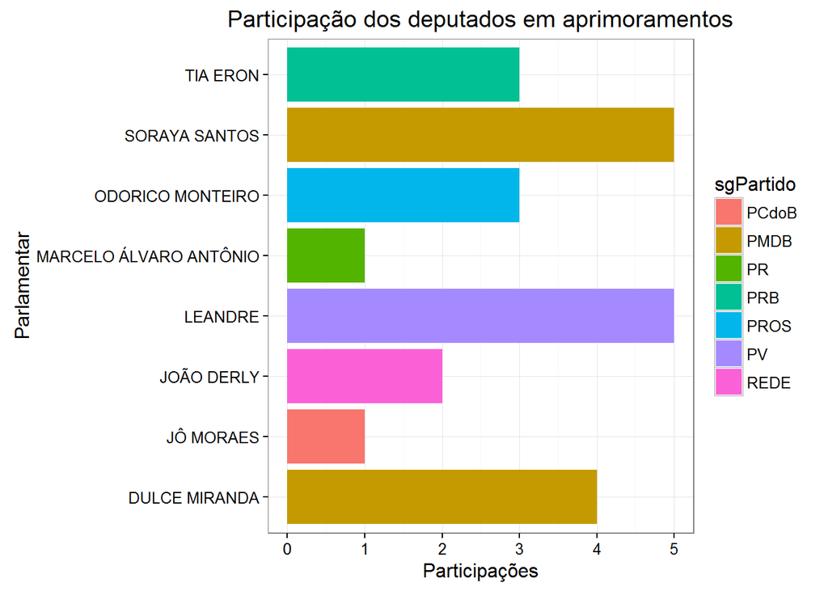

```r
ggplot(data=dados_palestras, mapping=aes(x=txNomeParlamentar, fill=sgPartido)) +
  geom_bar() +
  coord_flip() +
  theme_bw() +
  labs(title="Participação dos deputados em aprimoramentos", x="Parlamentar", y="Participações")
```

Além disso, desses parlamentares que participaram de eventos de aprimoramento, podemos ver agora quais foram os que mais gastaram e os que menos gastaram.

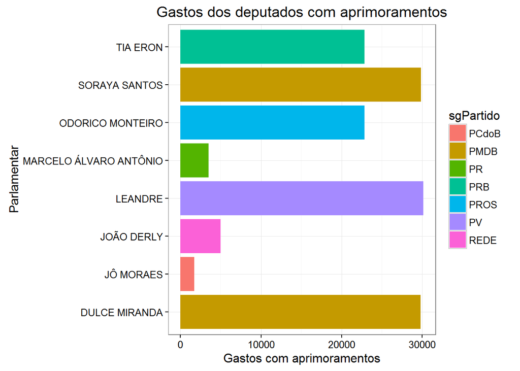

```r
gastos_palestras = dados_palestras %>%
  group_by(txNomeParlamentar) %>%
  summarise(total = sum(vlrLiquido)) %>%
  left_join(dados_palestras, by="txNomeParlamentar") %>%
  select(txNomeParlamentar, total, sgPartido) %>%
  distinct()

ggplot(data=gastos_palestras, mapping=aes(x=txNomeParlamentar, y=total, fill=sgPartido)) +
  geom_bar(stat="identity") +
  coord_flip() +
  theme_bw() +
  labs(title="Gastos dos deputados com aprimoramentos", x="Parlamentar", y="Gastos com aprimoramentos")
```

```r
deputados = dados %>%
  group_by(txNomeParlamentar) %>%
  summarise(total = n()) %>%
  distinct()

total_deputados = nrow(deputados)

total_deputados_s_qualificacao = nrow(deputados %>%
  anti_join(gastos_palestras, by="txNomeParlamentar"))
```

Agora, é possível observar que os deputados que mais gastaram com aprimoramentos foram a deputada Leandre do PV e as deputadas Soraya Santos e Dulce Miranda, ambas do PMDB. 564 deputados não gastaram com aprimoramentos no período, o que corresponde a 98.6% dos parlamentares. Um número bastante considerável, mas infelizmente pouco surpreendente.

### Os deputados que fretam mais aeronaves gastam menos em passagens aéreas?

Após obter informações sobre os gastos dos parlamentares com eventos de aprimoramento, vamos responder a nossa segunda pergunta. Nessa etapa queremos verificar se há alguma relação entre o total de fretamento de aeronaves e o total gasto em passagens aéreas.

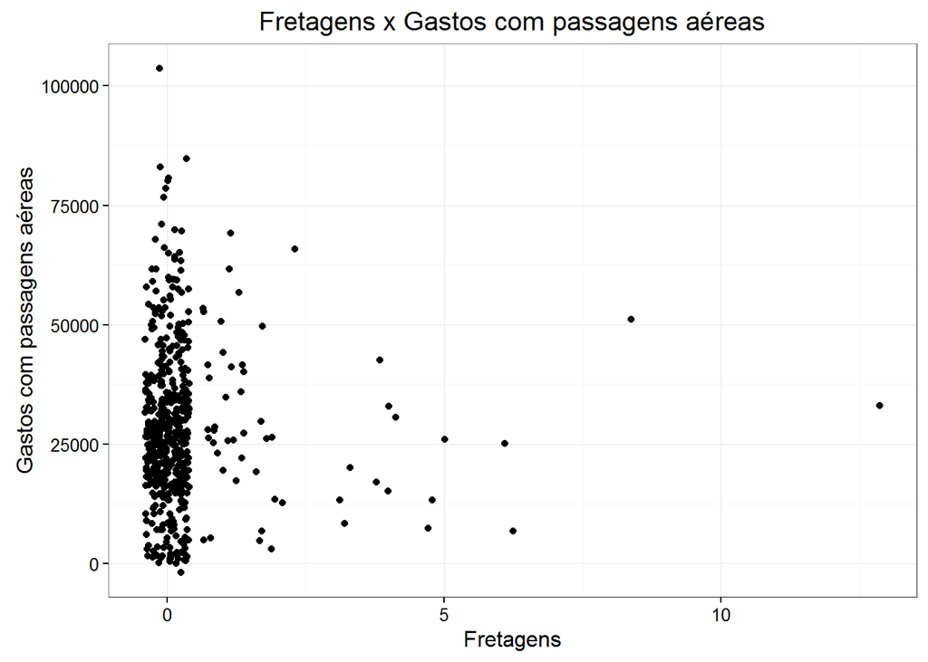

```r
fretagens_por_deputado = dados %>%
  filter(txtDescricao == "LOCAÇÃO OU FRETAMENTO DE AERONAVES") %>%
  group_by(txNomeParlamentar) %>%
  summarise(total_fretagens = n()) %>%
  distinct()

gastosp_por_deputado = dados %>%
  filter(txtDescricao %in% c("Emissão Bilhete Aéreo", "PASSAGENS AÉREAS")) %>%
  filter(!(txNomeParlamentar %in% c("LIDERANÇA DO PSDB", "LIDERANÇA DO PT"))) %>%
  group_by(txNomeParlamentar) %>%
  summarise(total_gasto = sum(vlrLiquido))

gastos_fretagens = fretagens_por_deputado %>%
  full_join(gastosp_por_deputado) %>%
  mutate(total_fretagens = ifelse(is.na(total_fretagens), 0, total_fretagens))

ggplot(data=gastos_fretagens, mapping=aes(x=total_fretagens, y=total_gasto)) +
  geom_point(position = "jitter") +
  theme_bw() +
  labs(title="Fretagens x Gastos com passagens aéreas", x="Fretagens", y="Gastos com passagens aéreas")
```

Utilizando apenas o gráfico, é difícil afirmar se de fato existe correlação entre as duas variáveis, mas aparentemente, há uma fraca relação negativa entre elas.  
Excetuando-se os deputados que não gastaram com fretagens, cujos gastos concentram-se em valores próximos de R$25.000, parece que quando os gastos com fretagens aumentam, os gastos com passagens aéreas diminuem. Porém, é necessário investigar mais a fundo essa possível correlação utilizando testes mais avançados.